# Anàlisi exploratòria inicial i neteja de les dades

Aquest notebook conte les etapes d'exploració inicial per comprendre millor el contingut de les dades, tot i disposar de l'article descriptiu https://www.sciencedirect.com/science/article/pii/S2352340921007708?via%3Dihub associat a les dades que ja ens dona algunes indicacions sobre com s'han obtingut les dades i el seu contingut. A continuació es realitza una integració de les dades de diferents fonts (o conjunts de dades en aquest cas) i es genera un conjunt de dades amb informació complementària que s'extreu de l'article. També es duu a terme l'etapa de neteja de dades, on entre altres tasques s'interpolen valors perduts. En diversos punts es descarten variables que ja no seran d'utilitat i es creen de noves que poden ser útils. Les dades resultants poden tenir variables que poden arribar a ser redundants entre elles per tenir l'opció de triar quina ens interessa més segons l'etapa del cicle de les dades o la tasca en la qual ens trobem. Com és difícil, predir les necessitats futures es desen les dades en tres conjunt de dades un amb les dades procedents del conjunt de dades en cru (amb les corresponents modificacions) (co2_rocords_analisi), una versió d'aquest conjunt de dades però amb les dades en un format adequat per a la creació de models (co2_rocords_models) i un amb les dades que hem extret íntegrament de l'article (co2_additional).

Es poden descarregar les dades a: https://zenodo.org/records/5062837

Per tal de reproduir els resultats, noteu que el conjunt de dades *CEIP_SantMiquel_Vilafames.csv* conté diversos signes de cometes(") que no esperàvem trobar en aquest arxiu i hem eliminat mitjançant un script per llegir el fitxer de forma habitual. Aquest notebook ha estat executat des de Kaggle i les rutes als arxius queden condicionades per aquest fet, per tal de reproduir-lo configureu correctament les rutes als arxius.

Es poden trobar explicacions amb més profunditat a la memòria de treball final de màster.

# Importar les llibreries i carregar les dades

```python
import pandas as pd
import numpy as np
from datetime import datetime
import pytz
import matplotlib.pyplot as plt
from sklearn.preprocessing import OneHotEncoder, minmax_scale
from sklearn.impute import KNNImputer
import warnings
```

```python
# Carregar dades
data_dir = "/kaggle/input/data-records/" #Modificar la ruta

albea_df = pd.read_csv(data_dir + "CEIP_LAlbea_ValldAba.csv")
santMiquel_df = pd.read_csv(data_dir + "CEIP_SantMiquel_Vilafames.csv")
```

# Anàlisi exploratori inicial

```python
display(albea_df.head())
display(santMiquel_df.head())
```

|  | published_at | date_time | date | month | w_day | time | hour | mint | sec | temp | hum | co2 | bat | sensor_id |
| --- | --- | --- | --- | --- | --- | --- | --- | --- | --- | --- | --- | --- | --- | --- |
| 0 | 2021-06-01T14:30:06.735Z | 2021-06-01T14:30:06 | 2021-06-01 | Jun | Tue | 14:30:06 | 14 | 30 | 6 | 29.84 | 46.33 | 390 | 85.19 | CO2_01 |
| 1 | 2021-06-01T14:15:06.784Z | 2021-06-01T14:15:06 | 2021-06-01 | Jun | Tue | 14:15:06 | 14 | 15 | 6 | 29.82 | 47.53 | 391 | 81.14 | CO2_01 |
| 2 | 2021-06-01T14:20:06.733Z | 2021-06-01T14:20:06 | 2021-06-01 | Jun | Tue | 14:20:06 | 14 | 20 | 6 | 29.83 | 47.24 | 391 | 82.49 | CO2_01 |
| 3 | 2021-06-01T14:35:06.728Z | 2021-06-01T14:35:06 | 2021-06-01 | Jun | Tue | 14:35:06 | 14 | 35 | 6 | 29.87 | 46.07 | 393 | 86.54 | CO2_01 |
| 4 | 2021-06-01T14:40:06.729Z | 2021-06-01T14:40:06 | 2021-06-01 | Jun | Tue | 14:40:06 | 14 | 40 | 6 | 29.96 | 45.92 | 395 | 87.90 | CO2_01 |

|  | published_at | date_time | date | month | w_day | hour | mint | sec | temp | hum | co2 | bat | sensor_id |
| --- | --- | --- | --- | --- | --- | --- | --- | --- | --- | --- | --- | --- | --- |
| 0 | 2021-05-03T07:00:05.241Z | 2021-05-03T07:00:05 | 5/3/2021 | May | Mon | 7 | 0 | 5 | 26.551460 | 39.382935 | 302 | 99.55 | CO2_06 |
| 1 | 2021-05-03T07:05:05.348Z | 2021-05-03T07:05:05 | 5/3/2021 | May | Mon | 7 | 5 | 5 | 26.479362 | 39.572144 | 301 | 99.55 | CO2_06 |
| 2 | 2021-05-03T07:20:05.162Z | 2021-05-03T07:20:05 | 5/3/2021 | May | Mon | 7 | 20 | 5 | 26.578163 | 40.089417 | 376 | 99.55 | CO2_06 |
| 3 | 2021-05-03T07:25:05.047Z | 2021-05-03T07:25:05 | 5/3/2021 | May | Mon | 7 | 25 | 5 | 26.749062 | 40.321350 | 520 | 99.55 | CO2_06 |
| 4 | 2021-05-03T07:35:04.554Z | 2021-05-03T07:35:04 | 5/3/2021 | May | Mon | 7 | 35 | 4 | 27.160294 | 39.421082 | 393 | 99.55 | CO2_06 |

```python
# Nombre de registres
print(f"Es disposen de {albea_df.shape[0]} registres de l'escola CEIP L'Albea de Vall d'Aba")
print(f"Es disposen de {santMiquel_df.shape[0]} registres de l'escola CEIP SantMiquel de Vilafames")
print(f"En total es disposen {albea_df.shape[0] + santMiquel_df.shape[0]} registres")
```

```
Es disposen de 34569 registres de l'escola CEIP L'Albea de Vall d'Aba
Es disposen de 38890 registres de l'escola CEIP SantMiquel de Vilafames
En total es disposen 73459 registres
```

```python
# Valors nuls
print(f"Nombre de valors nulls Albea: {albea_df.isna().sum().sum()}")
print(f"Nombre de valors nulls Sant Miquel: {santMiquel_df.isna().sum().sum()}")
```

```
Nombre de valors nulls Albea: 0
Nombre de valors nulls Sant Miquel: 0
```

```python
# Aproximació del nombre de registres perduts
registresAlbea = albea_df.groupby(['sensor_id', 'date']).size().reset_index(name='registres')
registresSantMiquel = santMiquel_df.groupby(['sensor_id', 'date']).size().reset_index(name='registres')
lostAlbea = (288 - registresAlbea['registres']).sum()
lostSantMiquel = (288 - registresSantMiquel['registres']).sum()
print(f"Aproximació de registres perdut:\nAlbea: {lostAlbea}\nSantMiquel: {lostSantMiquel}\nTotal: {lostAlbea+lostSantMiquel}")
```

```
Aproximació de registres perdut:
Albea: 3447
SantMiquel: 6326
Total: 9773
```

```python
# Descripció de les variables numèriques
display(albea_df.describe())
display(santMiquel_df.describe())
```

|  | hour | mint | sec | temp | hum | co2 | bat |
| --- | --- | --- | --- | --- | --- | --- | --- |
| count | 34569.000000 | 34569.000000 | 34569.000000 | 3.456900e+04 | 34569.000000 | 34569.000000 | 34569.000000 |
| mean | 11.546675 | 27.514565 | 5.300761 | -3.934161e+11 | 44.581813 | 464.838439 | 94.460135 |
| std | 6.945308 | 17.268860 | 1.007263 | 7.314683e+13 | 6.836175 | 134.195014 | 12.983063 |
| min | 0.000000 | 0.000000 | 3.000000 | -1.360000e+16 | 21.040000 | 358.000000 | 0.000000 |
| 25% | 5.000000 | 10.000000 | 5.000000 | 2.872000e+01 | 40.820000 | 415.000000 | 95.570000 |
| 50% | 12.000000 | 30.000000 | 5.000000 | 3.000000e+01 | 45.310000 | 429.000000 | 96.340000 |
| 75% | 18.000000 | 45.000000 | 6.000000 | 3.129000e+01 | 49.370000 | 448.000000 | 98.070000 |
| max | 23.000000 | 55.000000 | 38.000000 | 4.446000e+01 | 64.180000 | 1989.000000 | 100.000000 |

|  | hour | mint | sec | temp | hum | co2 | bat |
| --- | --- | --- | --- | --- | --- | --- | --- |
| count | 38890.000000 | 38890.000000 | 38890.000000 | 38890.000000 | 38890.000000 | 38890.000000 | 38890.000000 |
| mean | 11.614888 | 27.469555 | 5.497017 | 26.362428 | 41.705725 | 462.057136 | 90.565417 |
| std | 6.887407 | 17.254201 | 2.105269 | 1.942331 | 6.116020 | 75.125794 | 18.467512 |
| min | 0.000000 | 0.000000 | 0.000000 | 20.001144 | 14.300000 | 301.000000 | 0.000000 |
| 25% | 6.000000 | 10.000000 | 5.000000 | 25.100000 | 38.300000 | 417.000000 | 95.000000 |
| 50% | 12.000000 | 25.000000 | 5.000000 | 26.600000 | 42.600000 | 442.000000 | 95.570000 |
| 75% | 18.000000 | 40.000000 | 6.000000 | 27.800000 | 45.600000 | 479.000000 | 96.340000 |
| max | 23.000000 | 56.000000 | 59.000000 | 39.900000 | 63.900000 | 1213.000000 | 100.000000 |

```python
# Valors diferents variables categoriques
var_cat = ["month", "w_day","sensor_id"]
for var in var_cat:
    print(sorted(albea_df[var].unique()))
    print(sorted(santMiquel_df[var].unique()))
```

```
['Jun']
['May']
['Fri', 'Mon', 'Sat', 'Sun', 'Thu', 'Tue', 'Wed']
['Fri', 'Mon', 'Sat', 'Sun', 'Thu', 'Tue', 'Wed']
[' CO2_01', ' CO2_02', ' CO2_03', ' CO2_04', ' CO2_05', ' CO2_06']
[' CO2_01', ' CO2_02', ' CO2_03', ' CO2_04', ' CO2_05', ' CO2_06']
```

```python
# Tipus de dades
display(albea_df.dtypes)
display(santMiquel_df.dtypes)
```

```
published_at     object
date_time        object
date             object
month            object
w_day            object
time             object
hour              int64
mint              int64
sec               int64
temp            float64
hum             float64
co2               int64
bat             float64
sensor_id        object
dtype: object
```

```
published_at     object
date_time        object
date             object
month            object
w_day            object
hour              int64
mint              int64
sec               int64
temp            float64
hum             float64
co2               int64
bat             float64
sensor_id        object
dtype: object
```

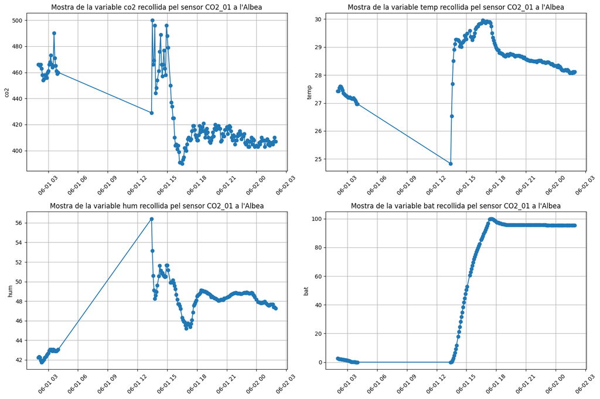

```python
# Crear el subset del día, sensor y lugar
subset = albea_df[(albea_df['date'] == "2021-06-01") & (albea_df['sensor_id'] == ' CO2_01')]

# Ordenar per date_time
subset = subset.sort_values(by='date_time')

# Crear una figura
fig, axs = plt.subplots(2, 2, figsize=(15, 10))

# Variables
variables = ["co2", "temp", "hum", "bat"]

# Graficar
for i, var in enumerate(variables):
    row = i // 2  # Calcular el número de fila
    col = i % 2   # Calcular el número de columna
    axs[row, col].plot(pd.to_datetime(subset['date_time'], utc=True).dt.tz_convert('Europe/Paris'), subset[var], marker='o', linestyle='-')
    axs[row, col].set_title("Mostra de la variable " + var + " recollida pel sensor CO2_01 a l'Albea")
    axs[row, col].set_ylabel(var)
    axs[row, col].grid(True)
    axs[row, col].tick_params(axis='x', rotation=45)

plt.tight_layout()

plt.show()
```

# Agregació i dades complementaries

```python
# Agregem els dos conjunts en un i afegim la columna location, corresponent a la ubicació
albea_df['location'] = 'Albea'
santMiquel_df['location'] = 'SantMiquel'
df = pd.concat([albea_df,santMiquel_df],ignore_index=True)

#Seleccionem variables
df = df[['date_time',
       'month',
       'w_day',
       'hour',
       'mint',
       'location',
       'sensor_id',
       'temp',
       'hum',
       'co2',]]
display(df.sample(n=5))
```

|  | date_time | month | w_day | hour | mint | location | sensor_id | temp | hum | co2 |
| --- | --- | --- | --- | --- | --- | --- | --- | --- | --- | --- |
| 60570 | 2021-05-23T00:45:04 | May | Sun | 0 | 45 | SantMiquel | CO2_05 | 25.80 | 47.00 | 416 |
| 16045 | 2021-06-15T13:40:06 | Jun | Tue | 13 | 40 | Albea | CO2_03 | 34.35 | 24.41 | 401 |
| 64999 | 2021-05-25T23:05:04 | May | Tue | 23 | 5 | SantMiquel | CO2_03 | 27.30 | 42.70 | 429 |
| 33602 | 2021-06-20T13:55:05 | Jun | Sun | 13 | 55 | Albea | CO2_06 | 31.89 | 46.50 | 444 |
| 12004 | 2021-06-22T06:20:04 | Jun | Tue | 6 | 20 | Albea | CO2_02 | 29.95 | 40.95 | 430 |

## Varibales grade, students, metres, windows i orientation

```python
variables_extra = {'location': ['SantMiquel','SantMiquel','SantMiquel','SantMiquel','SantMiquel','SantMiquel','Albea','Albea','Albea','Albea','Albea','Albea'],
    'sensor_id': ['CO2_01','CO2_02','CO2_03','CO2_04','CO2_05','CO2_06','CO2_01','CO2_02','CO2_03','CO2_04','CO2_05','CO2_06'],
                   'grade': [2, 6, 4, 1, 5, 3, 1, 6, 4, 5, 3, 2],
                   'students': [16, 18, 15, 17, 18, 17, 16, 20, 16, 14, 24, 25],
                   'square_metres': [39.56,43.37,43.37,49.61,43.37,43.37,35.8,65.3,67.0,69.17,44.56,40.9],
                   'windows': [3, 4, 4, 6, 4, 4, 2, 3, 4, 4, 2, 2],
                   'orientation': ['Playground','Street','Street','Playground','Street','Street','Playground','Playground','Playground','Playground','Playground','Playground']}
pd.DataFrame(variables_extra)
```

|  | location | sensor_id | grade | students | square_metres | windows | orientation |
| --- | --- | --- | --- | --- | --- | --- | --- |
| 0 | SantMiquel | CO2_01 | 2 | 16 | 39.56 | 3 | Playground |
| 1 | SantMiquel | CO2_02 | 6 | 18 | 43.37 | 4 | Street |
| 2 | SantMiquel | CO2_03 | 4 | 15 | 43.37 | 4 | Street |
| 3 | SantMiquel | CO2_04 | 1 | 17 | 49.61 | 6 | Playground |
| 4 | SantMiquel | CO2_05 | 5 | 18 | 43.37 | 4 | Street |
| 5 | SantMiquel | CO2_06 | 3 | 17 | 43.37 | 4 | Street |
| 6 | Albea | CO2_01 | 1 | 16 | 35.80 | 2 | Playground |
| 7 | Albea | CO2_02 | 6 | 20 | 65.30 | 3 | Playground |
| 8 | Albea | CO2_03 | 4 | 16 | 67.00 | 4 | Playground |
| 9 | Albea | CO2_04 | 5 | 14 | 69.17 | 4 | Playground |
| 10 | Albea | CO2_05 | 3 | 24 | 44.56 | 2 | Playground |
| 11 | Albea | CO2_06 | 2 | 25 | 40.90 | 2 | Playground |

```python
variables_extra = {'sensor_id': ['CO2_01','CO2_02','CO2_03','CO2_04','CO2_05','CO2_06','CO2_01','CO2_02','CO2_03','CO2_04','CO2_05','CO2_06'],
                   'location': ['SantMiquel','SantMiquel','SantMiquel','SantMiquel','SantMiquel','SantMiquel','Albea','Albea','Albea','Albea','Albea','Albea'],
                   'grade': [2, 6, 4, 1, 5, 3, 1, 6, 4, 5, 3, 2],
                   'students': [16, 18, 15, 17, 18, 17, 16, 20, 16, 14, 24, 25],
                   'square_metres': [39.56,43.37,43.37,49.61,43.37,43.37,35.8,65.3,67.0,69.17,44.56,40.9],
                   'windows': [3, 4, 4, 6, 4, 4, 2, 3, 4, 4, 2, 2],
                   'orientation': ['Playground','Street','Street','Playground','Street','Street','Playground','Playground','Playground','Playground','Playground','Playground']}
extra_df = pd.DataFrame(variables_extra)
# Nova variables que codifica els metres cuadrats per estudiant
#extra_df["student_square_metres"] = round(extra_df["square_metres"] / extra_df["students"],2)

#variables categoriques a numeriques
extra_df['location_id'] = extra_df['location'].map({'SantMiquel': 0, 'Albea': 1})
extra_df['orientation_id'] = extra_df['orientation'].map({'Playground': 0, 'Street': 1})

# Escalat de variables
columns_to_scale = ['grade','students', 'square_metres', 'windows']
columns_scaled = ['grade_scaled','students_scaled', 'square_metres_scaled', 'windows_scaled']
extra_df[columns_scaled] = minmax_scale(extra_df[columns_to_scale])
display(extra_df)
```

|  | sensor_id | location | grade | students | square_metres | windows | orientation | location_id | orientation_id | grade_scaled | students_scaled | square_metres_scaled | windows_scaled |
| --- | --- | --- | --- | --- | --- | --- | --- | --- | --- | --- | --- | --- | --- |
| 0 | CO2_01 | SantMiquel | 2 | 16 | 39.56 | 3 | Playground | 0 | 0 | 0.2 | 0.181818 | 0.112676 | 0.25 |
| 1 | CO2_02 | SantMiquel | 6 | 18 | 43.37 | 4 | Street | 0 | 1 | 1.0 | 0.363636 | 0.226850 | 0.50 |
| 2 | CO2_03 | SantMiquel | 4 | 15 | 43.37 | 4 | Street | 0 | 1 | 0.6 | 0.090909 | 0.226850 | 0.50 |
| 3 | CO2_04 | SantMiquel | 1 | 17 | 49.61 | 6 | Playground | 0 | 0 | 0.0 | 0.272727 | 0.413845 | 1.00 |
| 4 | CO2_05 | SantMiquel | 5 | 18 | 43.37 | 4 | Street | 0 | 1 | 0.8 | 0.363636 | 0.226850 | 0.50 |
| 5 | CO2_06 | SantMiquel | 3 | 17 | 43.37 | 4 | Street | 0 | 1 | 0.4 | 0.272727 | 0.226850 | 0.50 |
| 6 | CO2_01 | Albea | 1 | 16 | 35.80 | 2 | Playground | 1 | 0 | 0.0 | 0.181818 | 0.000000 | 0.00 |
| 7 | CO2_02 | Albea | 6 | 20 | 65.30 | 3 | Playground | 1 | 0 | 1.0 | 0.545455 | 0.884028 | 0.25 |
| 8 | CO2_03 | Albea | 4 | 16 | 67.00 | 4 | Playground | 1 | 0 | 0.6 | 0.181818 | 0.934972 | 0.50 |
| 9 | CO2_04 | Albea | 5 | 14 | 69.17 | 4 | Playground | 1 | 0 | 0.8 | 0.000000 | 1.000000 | 0.50 |
| 10 | CO2_05 | Albea | 3 | 24 | 44.56 | 2 | Playground | 1 | 0 | 0.4 | 0.909091 | 0.262511 | 0.00 |
| 11 | CO2_06 | Albea | 2 | 25 | 40.90 | 2 | Playground | 1 | 0 | 0.2 | 1.000000 | 0.152832 | 0.00 |

## Variable occupated

```python
time_table = {
    "SantMiquel":{
        "CO2_01":{
            "Mon":["09:30-11:00","11:30-13:00","15:30-17:00"],
            "Tue":["10:15-11:00","11:30-13:00","15:30-17:00"],
            "Wed":["09:30-11:00","11:30-13:00","15:30-17:00"],
            "Thu":["09:30-11:00","11:30-13:00"],
            "Fri":["09:30-11:00","11:30-13:00","15:30-17:00"]},
        "CO2_02":{
            "Mon":["09:30-11:45","12:15-13:00","15:30-17:00"],
            "Tue":["09:30-11:45","15:30-17:00"],
            "Wed":["11:00-11:45","12:15-13:00","15:30-17:00"],
            "Thu":["09:30-11:45","12:15-13:00","15:30-17:00"],
            "Fri":["09:30-11:45","12:15-13:00","15:30-17:00"]},
        "CO2_03":{
            "Mon":["09:30-11:45","15:30-17:00"],
            "Tue":["09:30-11:45","12:15-13:00","15:30-17:00"],
            "Wed":["09:30-11:45","12:15-13:00","15:30-17:00"],
            "Thu":["09:30-11:45","12:15-13:00"],
            "Fri":["09:30-11:45","12:15-13:00","15:30-17:00"]},
        "CO2_04":{
            "Mon":["09:30-11:00","11:30-13:00","15:30-17:00"],
            "Tue":["09:30-10:15","15:30-17:00"],
            "Wed":["09:30-11:00","11:30-13:00","15:30-17:00"],
            "Thu":["09:30-11:00","11:30-13:00","15:30-17:00"],
            "Fri":["09:30-11:00","11:30-13:00"]},
        "CO2_05":{
            "Mon":["10:15-11:45","12:15-13:00","15:30-17:00"],
            "Tue":["11:00-11:45","12:15-13:00","15:30-17:00"],
            "Wed":["11:00-11:45","12:15-13:00","15:30-17:00"],
            "Thu":["09:30-11:45","12:15-13:00","15:30-17:00"],
            "Fri":["09:30-11:45","12:15-13:00","15:30-17:00"]},

        "CO2_06":{
            "Mon":["09:30-11:45","12:15-13:00","15:30-17:00"],
            "Tue":["09:30-11:45","15:30-17:00"],
            "Wed":["09:30-11:45","12:15-13:00"],
            "Thu":["09:30-11:45","12:15-13:00","15:30-17:00"],
            "Fri":["09:30-11:45","12:15-13:00","15:30-17:00"]}},
    "Albea":{
        "CO2_01":{
            "Mon":["09:45-11:00","11:30-13:00"],
            "Tue":["09:30-11:00","11:30-13:00"],
            "Wed":["09:30-11:00","11:30-13:00"],
            "Thu":["09:30-11:00","11:30-13:00"],
            "Fri":["09:30-11:00","11:30-12:00"]},
        "CO2_02":{
            "Mon":["09:00-11:00","12:15-13:00"],
            "Tue":["10:00-11:00","11:30-13:00"],
            "Wed":["09:00-11:00","11:30-13:00"],
            "Thu":["09:00-11:00","11:30-13:00"],
            "Fri":["09:00-11:00","11:30-13:00"]},
        "CO2_03":{
            "Mon":["09:00-11:00","11:30-13:00"],
            "Tue":["09:00-11:00","11:30-12:15"],
            "Wed":["09:00-10:00","11:30-13:00"],
            "Thu":["09:00-11:00","11:30-13:00"],
            "Fri":["09:00-11:00","11:30-13:00"]},
        "CO2_04":{
            "Mon":["09:00-11:00","11:30-13:00"],
            "Tue":["09:00-11:00","11:30-13:00"],
            "Wed":["09:00-11:00","11:30-13:00"],
            "Thu":["09:00-10:00","11:30-13:00"],
            "Fri":["09:00-11:00","11:30-13:00"]},
        "CO2_05":{
            "Mon":["09:00-11:00","12:15-13:00"],
            "Tue":["09:00-11:00","11:30-13:00"],
            "Wed":["09:00-11:00","11:30-13:00"],
            "Thu":["09:00-11:00","12:15-13:30"],
            "Fri":["09:00-10:00","11:00-13:30"]},
        "CO2_06":{
            "Mon":["09:00-11:00","11:30-13:00"],
            "Tue":["09:00-11:00","11:30-13:00"],
            "Wed":["09:00-11:00","11:30-13:00"],
            "Thu":["09:00-10:00","11:30-12:15"],
            "Fri":["09:45-11:00","11:30-13:00"]}}}
outside = {
    "SantMiquel":{
        "May":{
            "CO2_01":{
                14:["13:00-17:00"]},
            "CO2_02":{
                20:["09:30-17:00"]},
            "CO2_03":{
                13:["13:00-17:00"]},
            "CO2_04":{
                7:["13:00-17:00"]},
            "CO2_05":{
                3:["09:30-13:00"]},
            "CO2_06":{
                12:["13:00-17:00"]}}},
    "Albea":{
        "Jun":{
            'CO2_01': {
                14: ['09:15-10:15'],
                16: ['11:00-12:00'],
                18: ['09:30-10:30'],
                21: ['11:00-12:00', '12:30-13:00'],
                22: ['09:30-10:30', '12:00-13:00'],
                23: ['09:00-13:00']},
             'CO2_02': {15: ['12:00-13:00'],
                17: ['09:00-10:00'],
                18: ['11:40-12:20'],
                21: ['09:15-11:00', '12:30-13:00'],
                22: ['09:30-10:00', '11:00-12:00'],
                23: ['09:00-13:00']},
             'CO2_03': {14: ['10:15-11:00'],
                16: ['09:00-10:00'],
                18: ['09:00-09:45'],
                21: ['09:15-11:00', '12:30-13:00'],
                22: ['09:30-10:30', '11:00-12:00'],
                23: ['09:00-13:00']},
             'CO2_04': {14: ['12:00-13:00'],
                15: ['11:30-12:15'],
                18: ['10:20-11:00'],
                21: ['09:15-11:00', '12:30-13:00'],
                22: ['09:30-10:30', '11:00-12:00'],
                23: ['09:00-13:00']},
             'CO2_05': {15: ['09:15-10:15'],
                16: ['11:00-12:00'],
                17: ['12:00-13:00'],
                21: ['11:00-12:00', '12:30-13:00'],
                22: ['09:30-10:30', '12:00-13:00'],
                23: ['09:00-13:00']},
             'CO2_06': {15: ['09:15-10:15'],
                16: ['11:00-12:00'],
                17: ['11:00-12:00'],
                21: ['11:00-12:00', '12:30-13:00'],
                22: ['09:30-10:30', '12:00-13:00'],
                23: ['09:00-13:00']}}}}
```

# Neteja de les dades

## Variable sensor_id

```python
# Eliminem els espais a la variable sensor_id
df['sensor_id'] = df['sensor_id'].str.strip()
```

## Variables temporals

```python
# Transformem la variable date_time com a tipus datetime, transformem les hores utc a horari europeu
df['date_time'] = pd.to_datetime(df['date_time'], utc=True).dt.tz_convert('Europe/Paris')

# Arrodonim date_time
df['date_time'] = df['date_time'].dt.floor('min')- pd.to_timedelta(df['date_time'].dt.minute % 5, unit='m')

# Apliquem els corresponents canvis a les variables hour, mint i w_day
df['hour'] = df['date_time'].dt.hour
df['mint'] = df['date_time'].dt.minute
dies_setmana = {0: 'Mon', 1: 'Tue', 2: 'Wed', 3: 'Thu', 4: 'Fri', 5: 'Sat', 6: 'Sun'}
df['w_day'] = df['date_time'].dt.dayofweek.map(dies_setmana)

# Nova variable que conté el dia del més
df['m_day'] = df['date_time'].dt.day

display(df.head())
```

|  | date_time | month | w_day | hour | mint | location | sensor_id | temp | hum | co2 | m_day |
| --- | --- | --- | --- | --- | --- | --- | --- | --- | --- | --- | --- |
| 0 | 2021-06-01 16:30:00+02:00 | Jun | Tue | 16 | 30 | Albea | CO2_01 | 29.84 | 46.33 | 390 | 1 |
| 1 | 2021-06-01 16:15:00+02:00 | Jun | Tue | 16 | 15 | Albea | CO2_01 | 29.82 | 47.53 | 391 | 1 |
| 2 | 2021-06-01 16:20:00+02:00 | Jun | Tue | 16 | 20 | Albea | CO2_01 | 29.83 | 47.24 | 391 | 1 |
| 3 | 2021-06-01 16:35:00+02:00 | Jun | Tue | 16 | 35 | Albea | CO2_01 | 29.87 | 46.07 | 393 | 1 |
| 4 | 2021-06-01 16:40:00+02:00 | Jun | Tue | 16 | 40 | Albea | CO2_01 | 29.96 | 45.92 | 395 | 1 |

## Registres duplicats

```python
# Registres duplicats
subset = [ 'month','m_day','w_day','hour','mint','location','sensor_id']
n_duplicats = df[df.duplicated(subset=subset)].shape[0]
print("Hi ha ", n_duplicats, " registres duplicats")
```

```
Hi ha  582  registres duplicats
```

```python
# Drop duplicats
df = df.drop_duplicates(subset=subset).reset_index(drop=True)
print(f"Després d'eliminar els dupliats queden {df.shape[0]} registres")
```

```
Després d'eliminar els dupliats queden 72877 registres
```

## Valors outliers

```python
# Registres amb valors fora dels rangs
outliers = df[(df['co2'] < 0) | (df['co2'] > 40000) |
   (df['temp'] < -40) | (df['temp'] > 79) |
   (df['hum'] < 0) | (df['hum'] > 100)]
display(outliers)
```

|  | date_time | month | w_day | hour | mint | location | sensor_id | temp | hum | co2 | m_day |
| --- | --- | --- | --- | --- | --- | --- | --- | --- | --- | --- | --- |
| 15888 | 2021-06-14 06:50:00+02:00 | Jun | Mon | 6 | 50 | Albea | CO2_03 | -1.360000e+16 | 34.17 | 445 | 14 |

```python
df.loc[df['temp'] < -40, 'temp'] = None #perque no afecti a la mitjana

aux = df.loc[(df['date_time'] >= '2021-06-14T06:40:00')
               & (df['date_time'] <= '2021-06-14T06:55:00')
               & (df['sensor_id'] == "CO2_03")
               & (df['location'] == "Albea")]
display(aux.sort_values(by='date_time'))
```

|  | date_time | month | w_day | hour | mint | location | sensor_id | temp | hum | co2 | m_day |
| --- | --- | --- | --- | --- | --- | --- | --- | --- | --- | --- | --- |
| 15887 | 2021-06-14 06:40:00+02:00 | Jun | Mon | 6 | 40 | Albea | CO2_03 | 31.12 | 34.36 | 445 | 14 |
| 15888 | 2021-06-14 06:50:00+02:00 | Jun | Mon | 6 | 50 | Albea | CO2_03 | NaN | 34.17 | 445 | 14 |
| 15885 | 2021-06-14 06:55:00+02:00 | Jun | Mon | 6 | 55 | Albea | CO2_03 | 31.09 | 33.94 | 444 | 14 |

```python
# Interpolem el valor
mitjana = round(aux["temp"].mean(),2)
df = df.fillna(mitjana)
```

## Registres perduts

```python
warnings.filterwarnings('ignore', category=FutureWarning)

diff_df = pd.DataFrame(columns=['diff', 'count'])
gaps = {}

for location in df["location"].unique():
    for sensor_id in df["sensor_id"].unique():
        subset = df[(df['location'] == location) & (df['sensor_id'] == sensor_id)].sort_values(by='date_time')
        aux_df = subset['date_time'].diff().reset_index(name='time_gap').groupby(['time_gap']).size().reset_index(name='cases_count')
        diff_df = pd.concat([diff_df,aux_df],ignore_index=True)

diff_df = diff_df.groupby('time_gap').agg({'cases_count': 'sum'}).reset_index()
diff_df["cases_count"] = diff_df["cases_count"].astype(int)
diff_df["registers_gap"] = (diff_df["time_gap"] / pd.Timedelta(minutes=5) - 1).astype(int)
diff_df["total_registers_lost"] = diff_df["registers_gap"] * diff_df["cases_count"].astype(int)
diff_df['registers_lost_acumulative'] = diff_df['total_registers_lost'].cumsum()

total = diff_df["total_registers_lost"].sum()

diff_df['registers_lost_acumulative_global(%)']= round(diff_df["registers_lost_acumulative"] / (df.shape[0]+total) *100,4)
diff_df = diff_df[["time_gap","registers_gap","cases_count","total_registers_lost","registers_lost_acumulative",'registers_lost_acumulative_global(%)']]

# display(diff_df) # per veure els resultats complets
display(diff_df.head(10))
display(diff_df.tail())

print(f"Els registres perduts representen un {round(total/(df.shape[0]+total) *100,4)}% sobre el máxim(teóric) nombre de registres possibles")
print(f"Imputar tots els valor respresentaria afegir {round(total/df.shape[0] *100,2)}% més de registres")
```

|  | time_gap | registers_gap | cases_count | total_registers_lost | registers_lost_acumulative | registers_lost_acumulative_global(%) |
| --- | --- | --- | --- | --- | --- | --- |
| 0 | 0 days 00:05:00 | 0 | 68996 | 0 | 0 | 0.0000 |
| 1 | 0 days 00:10:00 | 1 | 3569 | 3569 | 3569 | 4.2454 |
| 2 | 0 days 00:15:00 | 2 | 199 | 398 | 3967 | 4.7188 |
| 3 | 0 days 00:20:00 | 3 | 26 | 78 | 4045 | 4.8116 |
| 4 | 0 days 00:25:00 | 4 | 10 | 40 | 4085 | 4.8592 |
| 5 | 0 days 00:30:00 | 5 | 8 | 40 | 4125 | 4.9067 |
| 6 | 0 days 00:35:00 | 6 | 8 | 48 | 4173 | 4.9638 |
| 7 | 0 days 00:40:00 | 7 | 4 | 28 | 4201 | 4.9971 |
| 8 | 0 days 00:45:00 | 8 | 7 | 56 | 4257 | 5.0638 |
| 9 | 0 days 00:50:00 | 9 | 1 | 9 | 4266 | 5.0745 |

|  | time_gap | registers_gap | cases_count | total_registers_lost | registers_lost_acumulative | registers_lost_acumulative_global(%) |
| --- | --- | --- | --- | --- | --- | --- |
| 36 | 2 days 02:20:00 | 603 | 1 | 603 | 8192 | 9.7445 |
| 37 | 2 days 03:05:00 | 612 | 1 | 612 | 8804 | 10.4725 |
| 38 | 2 days 03:10:00 | 613 | 1 | 613 | 9417 | 11.2016 |
| 39 | 2 days 03:50:00 | 621 | 1 | 621 | 10038 | 11.9403 |
| 40 | 4 days 00:10:00 | 1153 | 1 | 1153 | 11191 | 13.3118 |

```
Els registres perduts representen un 13.3118% sobre el máxim(teóric) nombre de registres possibles
Imputar tots els valor respresentaria afegir 15.36% més de registres
```

```python
df.shape[0]+total
```

```
84068
```

```python
perduts_df = []

# df amb els date_time perduts
for location in df["location"].unique():
    for sensor_id in df["sensor_id"].unique():
        sub_df = df[(df["location"] == location) & (df["sensor_id"] == sensor_id)].sort_values(by='date_time').reset_index(drop=True)

        start_time = min(sub_df["date_time"])
        end_time = max(sub_df["date_time"])
        time_range = pd.date_range(start=start_time, end=end_time, freq='5T')

        sub_df_times = set(sub_df['date_time'])

        missing_times = [time for time in time_range if time not in sub_df_times]

        missing_df = pd.DataFrame(missing_times, columns=['date_time'])

        # Resta de variables
        missing_df["month"] = missing_df['date_time'].dt.month.map({5:"May", 6:"Jun"})
        missing_df["w_day"] = missing_df['date_time'].dt.dayofweek.map(dies_setmana)
        missing_df["hour"] = missing_df['date_time'].dt.hour
        missing_df["mint"] = missing_df['date_time'].dt.minute
        missing_df["location"] = location
        missing_df["sensor_id"] = sensor_id
        missing_df["temp"] = np.nan
        missing_df["hum"] = np.nan
        missing_df["co2"] = np.nan
        missing_df["m_day"] = missing_df['date_time'].dt.day
        missing_df['imputed'] = 1

        perduts_df.append(missing_df)

registres_creats = sum(len(missing_df) for missing_df in perduts_df)
print(f"S'han generat els registres dels {registres_creats} registres perduts")
# Juntem les dades originals i les perdudes
# Recordatori: Encara no hem imputat valors
df['imputed'] = 0
df = pd.concat([df] + perduts_df,ignore_index=True)
display(df.sample(n=12))
```

```
S'han generat els registres dels 11191 registres perduts
```

|  | date_time | month | w_day | hour | mint | location | sensor_id | temp | hum | co2 | m_day | imputed |
| --- | --- | --- | --- | --- | --- | --- | --- | --- | --- | --- | --- | --- |
| 16947 | 2021-06-18 23:30:00+02:00 | Jun | Fri | 23 | 30 | Albea | CO2_03 | 32.66 | 44.860000 | 426.0 | 18 | 0 |
| 5358 | 2021-06-21 22:10:00+02:00 | Jun | Mon | 22 | 10 | Albea | CO2_01 | 29.96 | 31.770000 | 405.0 | 21 | 0 |
| 2204 | 2021-06-09 04:35:00+02:00 | Jun | Wed | 4 | 35 | Albea | CO2_01 | 27.38 | 52.800000 | 435.0 | 9 | 0 |
| 83646 | 2021-05-10 08:40:00+02:00 | May | Mon | 8 | 40 | SantMiquel | CO2_06 | NaN | NaN | NaN | 10 | 1 |
| 83693 | 2021-05-12 04:40:00+02:00 | May | Wed | 4 | 40 | SantMiquel | CO2_06 | NaN | NaN | NaN | 12 | 1 |
| 20995 | 2021-06-09 11:10:00+02:00 | Jun | Wed | 11 | 10 | Albea | CO2_04 | 27.32 | 58.200000 | 1104.0 | 9 | 0 |
| 40351 | 2021-05-10 11:40:00+02:00 | May | Mon | 11 | 40 | SantMiquel | CO2_01 | 24.50 | 41.201782 | 427.0 | 10 | 0 |
| 49390 | 2021-05-16 02:40:00+02:00 | May | Sun | 2 | 40 | SantMiquel | CO2_05 | 25.80 | 39.900000 | 440.0 | 16 | 0 |
| 26973 | 2021-06-18 00:30:00+02:00 | Jun | Fri | 0 | 30 | Albea | CO2_05 | 31.44 | 47.530000 | 419.0 | 18 | 0 |
| 73796 | 2021-06-18 10:35:00+02:00 | Jun | Fri | 10 | 35 | Albea | CO2_02 | NaN | NaN | NaN | 18 | 1 |
| 58275 | 2021-05-21 19:10:00+02:00 | May | Fri | 19 | 10 | SantMiquel | CO2_04 | 25.10 | 53.700000 | 539.0 | 21 | 0 |
| 48754 | 2021-05-15 17:25:00+02:00 | May | Sat | 17 | 25 | SantMiquel | CO2_04 | 24.10 | 38.100000 | 408.0 | 15 | 0 |

## Prova knn (No resulta)

Imputació dels valors temperatura utilitzant els valors dels quals si disposem d'altres sensors a la mateixa localització i el mateix moment per trobar mitjançant knn quin son els 5 registres de valors més propers i realitzar una imputació fent la mitjana d'aquests valors. En altres paraules utilitzem les temperatures de la mateixa localització per trobar moments semblants en relació amb la temperatura i imputar aquests valors. Interpolarem tots els valors que la tècnica permeti.

```python
from sklearn.impute import KNNImputer

df_copy = df[df['location'] == 'Albea'].copy()

pivot_df = df_copy.pivot_table(index='date_time', columns='sensor_id', values='temp')

imputer = KNNImputer(n_neighbors=5)

knn_df = pd.DataFrame(imputer.fit_transform(pivot_df), columns=pivot_df.columns, index=pivot_df.index)

for index, row in df_copy.iterrows():
        try:
            df_copy.loc[index, 'temp'] = knn_df.loc[row["date_time"], row["sensor_id"]]
        except:
            pass
```

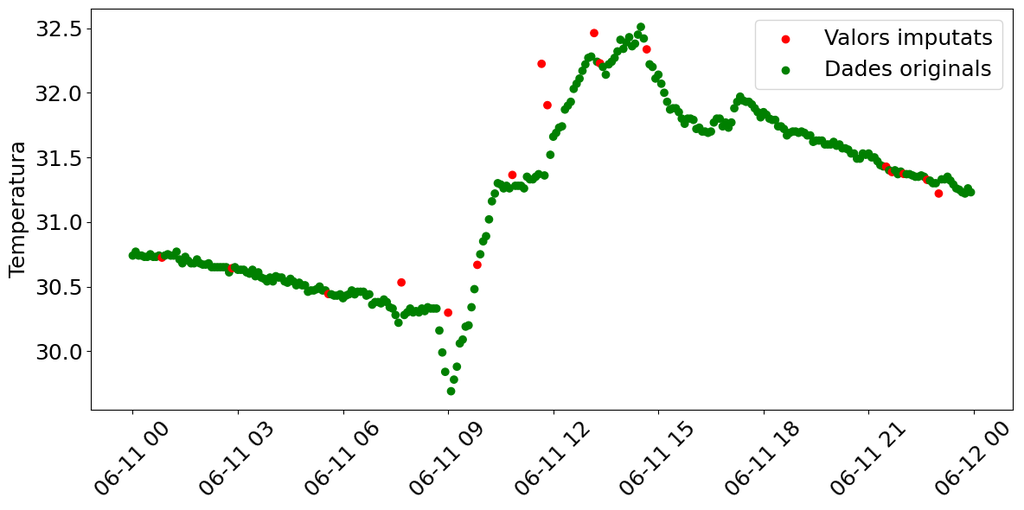

```python
subset = df_copy[(df_copy["date_time"].dt.day == 11)  & (df_copy["sensor_id"] == "CO2_03")].sort_values(by='date_time')

plt.figure(figsize=(12, 6))
colors = subset['imputed'].map({0: 'green', 1: 'red'})
plt.scatter(subset['date_time'], subset['temp'], c=colors)
plt.xlabel('')
plt.ylabel('Temperatura',fontsize=18)
plt.title('')
plt.xticks(rotation=45, fontsize=18)
plt.yticks(fontsize=18)
plt.scatter([], [], c='red', label='Valors imputats')
plt.scatter([], [], c='green', label='Dades originals')
plt.legend(fontsize=18)
plt.tight_layout()
plt.savefig('temperature_imputed.png')

plt.show()
```

## Interpolació lineal

```python
max_gap = 7

for location in df["location"].unique():
    for sensor_id in df["sensor_id"].unique():
        sub_df = df[(df["location"] == location) & (df["sensor_id"] == sensor_id)].sort_values(by='date_time')

        #Cerca dels gaps més grans que max_gap
        sub_df['hum_nan'] = sub_df['hum'].isna()
        sub_df['gap_id'] = (sub_df['hum_nan'] != sub_df['hum_nan'].shift()).cumsum()
        gap_sizes = sub_df.groupby('gap_id')['hum_nan'].transform('sum')
        sub_df['large_gap'] = (gap_sizes > max_gap) & sub_df['hum_nan']

        # Interpolem tot
        sub_df['temp'] = sub_df['temp'].interpolate(method='linear')
        sub_df['hum'] = sub_df['hum'].interpolate(method='linear')
        sub_df['co2'] = sub_df['co2'].interpolate(method='linear')

        #Tornem a nan els grans gaps
        sub_df.loc[sub_df['large_gap'], 'temp'] = np.nan
        sub_df.loc[sub_df['large_gap'], 'hum'] = np.nan
        sub_df.loc[sub_df['large_gap'], 'co2'] = np.nan

        sub_df = sub_df[["temp","hum",'co2']]

        df.update(sub_df)

print(f"Hi ha {len(df[df['temp'].isna()])} valors que no s'han imputat perquè pertanyen a gaps de més de {max_gap} valors")
display(df.sample(n=12))
```

```
Hi ha 6990 valors que no s'han imputat perquè pertanyen a gaps de més de 7 valors
```

|  | date_time | month | w_day | hour | mint | location | sensor_id | temp | hum | co2 | m_day | imputed |
| --- | --- | --- | --- | --- | --- | --- | --- | --- | --- | --- | --- | --- |
| 81199 | 2021-05-07 02:05:00+02:00 | May | Fri | 2 | 5 | SantMiquel | CO2_04 | 23.10 | 53.929138 | 523.5 | 7 | 1 |
| 20044 | 2021-06-06 14:55:00+02:00 | Jun | Sun | 14 | 55 | Albea | CO2_04 | 25.88 | 50.540000 | 430.0 | 6 | 0 |
| 64074 | 2021-05-25 16:45:00+02:00 | May | Tue | 16 | 45 | SantMiquel | CO2_04 | 24.60 | 47.800000 | 510.0 | 25 | 0 |
| 76406 | 2021-06-01 06:30:00+02:00 | Jun | Tue | 6 | 30 | Albea | CO2_05 | NaN | NaN | NaN | 1 | 1 |
| 58846 | 2021-05-22 03:30:00+02:00 | May | Sat | 3 | 30 | SantMiquel | CO2_05 | 26.80 | 46.500000 | 435.0 | 22 | 0 |
| 59366 | 2021-05-22 12:10:00+02:00 | May | Sat | 12 | 10 | SantMiquel | CO2_05 | 26.50 | 45.900000 | 432.0 | 22 | 0 |
| 58460 | 2021-05-21 21:55:00+02:00 | May | Fri | 21 | 55 | SantMiquel | CO2_03 | 25.50 | 50.800000 | 492.0 | 21 | 0 |
| 55152 | 2021-05-19 20:55:00+02:00 | May | Wed | 20 | 55 | SantMiquel | CO2_01 | 28.20 | 39.700000 | 506.0 | 19 | 0 |
| 24270 | 2021-06-07 17:15:00+02:00 | Jun | Mon | 17 | 15 | Albea | CO2_05 | 29.53 | 48.420000 | 426.0 | 7 | 0 |
| 68918 | 2021-05-28 18:00:00+02:00 | May | Fri | 18 | 0 | SantMiquel | CO2_04 | 25.40 | 47.800000 | 463.0 | 28 | 0 |
| 83909 | 2021-05-25 15:50:00+02:00 | May | Tue | 15 | 50 | SantMiquel | CO2_06 | 27.10 | 41.200000 | 477.5 | 25 | 1 |
| 59311 | 2021-05-22 11:10:00+02:00 | May | Sat | 11 | 10 | SantMiquel | CO2_01 | 27.00 | 44.500000 | 416.0 | 22 | 0 |

## Variable occupied

```python
occupied = [None] * df.shape[0]

for indice, fila in df.iterrows():
    # Dissabtes i diumenges
    if fila["w_day"] in ("Sat","Sun"):
        occupied[indice] = 0

    # Festiu especial 21 de maig
    elif fila["m_day"] == 21 and fila["month"] == "May":
        occupied[indice] = 0

    else:
        #Si s'ha dut a terme activitats fora del aula
        if fila["m_day"] in outside[fila["location"]][fila["month"]][fila["sensor_id"]]:
            for interval in outside[fila["location"]][fila["month"]][fila["sensor_id"]][fila["m_day"]]:
                hora_inicial, hora_final = interval.split('-')
                hora_minut = fila["date_time"].strftime("%H:%M")
                if hora_minut >= hora_inicial and hora_minut < hora_final:
                    occupied[indice] = 0
                    break

        #Si hi ha alumnes al aula
        if occupied[indice] is None:
            for interval in time_table[fila["location"]][fila["sensor_id"]][fila["w_day"]]:
                hora_inicial, hora_final = interval.split('-')
                hora_minut = fila["date_time"].strftime("%H:%M")
                if hora_minut >= hora_inicial and hora_minut < hora_final:
                    occupied[indice] = 1
                    break
            else:
                occupied[indice] = 0
df["occupied"] = occupied
display(df.sample(n=12))
```

|  | date_time | month | w_day | hour | mint | location | sensor_id | temp | hum | co2 | m_day | imputed | occupied |
| --- | --- | --- | --- | --- | --- | --- | --- | --- | --- | --- | --- | --- | --- |
| 74645 | 2021-06-17 00:35:00+02:00 | Jun | Thu | 0 | 35 | Albea | CO2_04 | NaN | NaN | NaN | 17 | 1 | 0 |
| 65688 | 2021-05-26 17:30:00+02:00 | May | Wed | 17 | 30 | SantMiquel | CO2_06 | 27.70 | 45.00 | 501.0 | 26 | 0 | 0 |
| 1054 | 2021-06-05 15:25:00+02:00 | Jun | Sat | 15 | 25 | Albea | CO2_01 | 26.58 | 51.48 | 405.0 | 5 | 0 | 0 |
| 11235 | 2021-06-20 02:55:00+02:00 | Jun | Sun | 2 | 55 | Albea | CO2_02 | 29.88 | 50.43 | 433.0 | 20 | 0 | 0 |
| 4369 | 2021-06-17 15:05:00+02:00 | Jun | Thu | 15 | 5 | Albea | CO2_01 | 29.45 | 51.84 | 413.0 | 17 | 0 | 0 |
| 9778 | 2021-06-15 23:00:00+02:00 | Jun | Tue | 23 | 0 | Albea | CO2_02 | 32.06 | 37.51 | 376.0 | 15 | 0 | 0 |
| 54221 | 2021-05-19 07:15:00+02:00 | May | Wed | 7 | 15 | SantMiquel | CO2_04 | 23.10 | 52.70 | 444.0 | 19 | 0 | 0 |
| 15801 | 2021-06-14 19:05:00+02:00 | Jun | Mon | 19 | 5 | Albea | CO2_03 | 33.17 | 29.15 | 425.0 | 14 | 0 | 0 |
| 78586 | 2021-05-08 12:55:00+02:00 | May | Sat | 12 | 55 | SantMiquel | CO2_03 | NaN | NaN | NaN | 8 | 1 | 0 |
| 31101 | 2021-06-12 21:15:00+02:00 | Jun | Sat | 21 | 15 | Albea | CO2_06 | 31.17 | 42.45 | 452.0 | 12 | 0 | 0 |
| 72631 | 2021-05-31 09:35:00+02:00 | May | Mon | 9 | 35 | SantMiquel | CO2_03 | 25.70 | 47.00 | 442.0 | 31 | 0 | 1 |
| 23884 | 2021-06-05 18:45:00+02:00 | Jun | Sat | 18 | 45 | Albea | CO2_05 | 33.80 | 38.69 | 444.0 | 5 | 0 | 0 |

## Variable d_record

```python
df["d_record"] = df["hour"] * 12 + df["mint"] // 5 # Hores i minut en una sola variable
display(df.head())
```

|  | date_time | month | w_day | hour | mint | location | sensor_id | temp | hum | co2 | m_day | imputed | occupied | d_record |
| --- | --- | --- | --- | --- | --- | --- | --- | --- | --- | --- | --- | --- | --- | --- |
| 0 | 2021-06-01 16:30:00+02:00 | Jun | Tue | 16 | 30 | Albea | CO2_01 | 29.84 | 46.33 | 390.0 | 1 | 0 | 0 | 198 |
| 1 | 2021-06-01 16:15:00+02:00 | Jun | Tue | 16 | 15 | Albea | CO2_01 | 29.82 | 47.53 | 391.0 | 1 | 0 | 0 | 195 |
| 2 | 2021-06-01 16:20:00+02:00 | Jun | Tue | 16 | 20 | Albea | CO2_01 | 29.83 | 47.24 | 391.0 | 1 | 0 | 0 | 196 |
| 3 | 2021-06-01 16:35:00+02:00 | Jun | Tue | 16 | 35 | Albea | CO2_01 | 29.87 | 46.07 | 393.0 | 1 | 0 | 0 | 199 |
| 4 | 2021-06-01 16:40:00+02:00 | Jun | Tue | 16 | 40 | Albea | CO2_01 | 29.96 | 45.92 | 395.0 | 1 | 0 | 0 | 200 |

# Preparació del dataset per entrenar models

```python
# Copia del dtaset
models_df = df.copy()
```

## w_day

```python
encoder = OneHotEncoder(sparse=False)

encoded_days = encoder.fit_transform(models_df[['w_day']])

column_names = encoder.categories_[0].tolist()

encoded_df = pd.DataFrame(encoded_days, columns=column_names)

models_df = pd.concat([models_df, encoded_df], axis=1)

display(models_df[['w_day'] + column_names].sample(n=5))
```

|  | w_day | Fri | Mon | Sat | Sun | Thu | Tue | Wed |
| --- | --- | --- | --- | --- | --- | --- | --- | --- |
| 9306 | Sun | 0.0 | 0.0 | 0.0 | 1.0 | 0.0 | 0.0 | 0.0 |
| 40522 | Mon | 0.0 | 1.0 | 0.0 | 0.0 | 0.0 | 0.0 | 0.0 |
| 14287 | Tue | 0.0 | 0.0 | 0.0 | 0.0 | 0.0 | 1.0 | 0.0 |
| 7620 | Mon | 0.0 | 1.0 | 0.0 | 0.0 | 0.0 | 0.0 | 0.0 |
| 68595 | Fri | 1.0 | 0.0 | 0.0 | 0.0 | 0.0 | 0.0 | 0.0 |

## d_record

```python
def codificador_ciclic(d_record):
    sin_d_record = np.sin(2 * np.pi * d_record / 288)
    cos_d_record = np.cos(2 * np.pi * d_record / 288)
    return sin_d_record, cos_d_record

models_df["sin_d_record"] , models_df["cos_d_record"] = codificador_ciclic(models_df["d_record"])

display(models_df[['d_record',"sin_d_record","cos_d_record"]].sample(n=5))
```

|  | d_record | sin_d_record | cos_d_record |
| --- | --- | --- | --- |
| 33293 | 30 | 0.608761 | 0.793353 |
| 27524 | 236 | -0.906308 | 0.422618 |
| 24761 | 8 | 0.173648 | 0.984808 |
| 40931 | 252 | -0.707107 | 0.707107 |
| 30061 | 69 | 0.997859 | 0.065403 |

```python
#selecció de variables
models_df = models_df[["date_time", "location", "sensor_id", "temp", "hum" , "co2", "occupied"] + column_names + ["sin_d_record","cos_d_record"]]

# escalat a [0,1]
columns_to_scale = ['temp','hum', 'co2', 'sin_d_record', 'cos_d_record']
models_df[columns_to_scale] = minmax_scale(models_df[columns_to_scale])

display(models_df.sample(n=6).sort_values(by='date_time'))
```

|  | date_time | location | sensor_id | temp | hum | co2 | occupied | Fri | Mon | Sat | Sun | Thu | Tue | Wed | sin_d_record | cos_d_record |
| --- | --- | --- | --- | --- | --- | --- | --- | --- | --- | --- | --- | --- | --- | --- | --- | --- |
| 44129 | 2021-05-12 21:50:00+02:00 | SantMiquel | CO2_06 | 0.290237 | 0.254611 | 0.045616 | 0 | 0.0 | 0.0 | 0.0 | 0.0 | 0.0 | 0.0 | 1.0 | 0.231350 | 0.921696 |
| 69697 | 2021-05-29 05:40:00+02:00 | SantMiquel | CO2_04 | 0.134874 | 0.761828 | 0.089455 | 0 | 0.0 | 0.0 | 1.0 | 0.0 | 0.0 | 0.0 | 0.0 | 0.998097 | 0.543578 |
| 767 | 2021-06-04 18:50:00+02:00 | Albea | CO2_01 | 0.284922 | 0.859864 | 0.061019 | 0 | 1.0 | 0.0 | 0.0 | 0.0 | 0.0 | 0.0 | 0.0 | 0.011852 | 0.608220 |
| 13630 | 2021-06-07 00:35:00+02:00 | Albea | CO2_03 | 0.374460 | 0.565758 | 0.063389 | 0 | 0.0 | 1.0 | 0.0 | 0.0 | 0.0 | 0.0 | 0.0 | 0.576062 | 0.994181 |
| 13829 | 2021-06-07 02:50:00+02:00 | Albea | CO2_03 | 0.373233 | 0.562951 | 0.069313 | 0 | 0.0 | 1.0 | 0.0 | 0.0 | 0.0 | 0.0 | 0.0 | 0.837795 | 0.868639 |
| 31402 | 2021-06-13 10:00:00+02:00 | Albea | CO2_06 | 0.446417 | 0.592823 | 0.083531 | 0 | 0.0 | 0.0 | 0.0 | 1.0 | 0.0 | 0.0 | 0.0 | 0.750000 | 0.066987 |

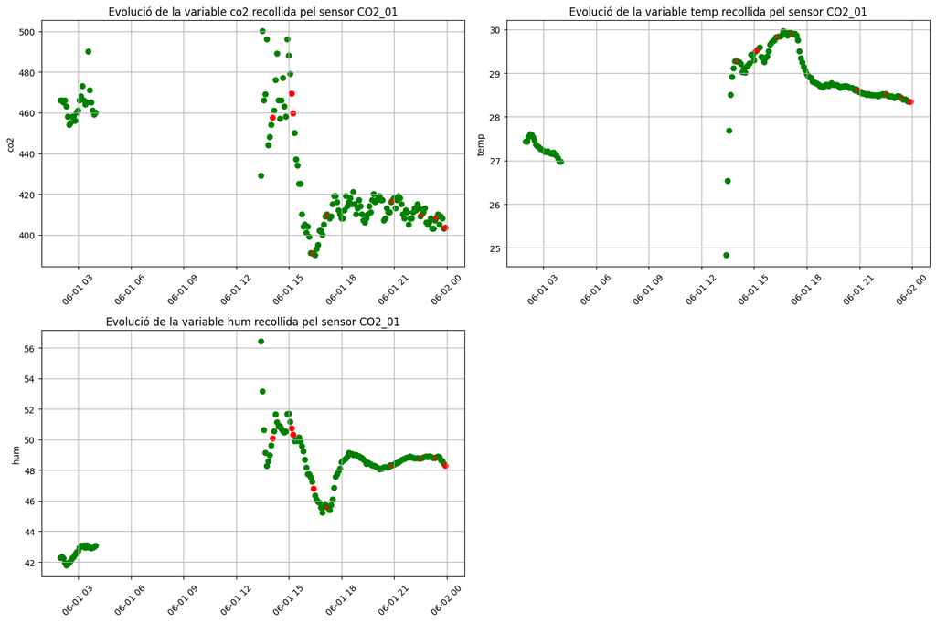

```python
subset = df[(df['m_day'] == 1) & (df['sensor_id'] == 'CO2_01') & (df['location'] == 'Albea')]

# Ordenar por date_time
subset = subset.sort_values(by='date_time')

# Crear una figura
fig, axs = plt.subplots(2, 2, figsize=(15, 10))

# Variables
variables = ["co2", "temp", "hum"]

# Graficar
for i, var in enumerate(variables):
    row = i // 2  # Calcular el número de fila
    col = i % 2   # Calcular el número de columna
    ax = axs[row, col]
    date_times = pd.to_datetime(subset['date_time'], utc=True).dt.tz_convert('Europe/Paris')
    colors = subset['imputed'].map({0: 'green', 1: 'red'})

    ax.scatter(date_times, subset[var], c=colors, marker='o')
    ax.set_title(f"Evolució de la variable {var} recollida pel sensor CO2_01")
    ax.set_ylabel(var)
    ax.grid(True)
    ax.tick_params(axis='x', rotation=45)

# Eliminar
fig.delaxes(axs[1, 1])

plt.tight_layout()
plt.show()
```

# Guardem els dataset

```python
# Eliminem registres amb valors nulls per l'analisi
df = df[df['hum'].notna() & df['temp'].notna() & df['co2'].notna()] #valdria amb una de les tres condicions ja que al final son la mateixa

df.to_csv("co2_records_analisi.csv", index=False)
display(df.head())
```

|  | date_time | month | w_day | hour | mint | location | sensor_id | temp | hum | co2 | m_day | imputed | occupied | d_record |
| --- | --- | --- | --- | --- | --- | --- | --- | --- | --- | --- | --- | --- | --- | --- |
| 0 | 2021-06-01 16:30:00+02:00 | Jun | Tue | 16 | 30 | Albea | CO2_01 | 29.84 | 46.33 | 390.0 | 1 | 0 | 0 | 198 |
| 1 | 2021-06-01 16:15:00+02:00 | Jun | Tue | 16 | 15 | Albea | CO2_01 | 29.82 | 47.53 | 391.0 | 1 | 0 | 0 | 195 |
| 2 | 2021-06-01 16:20:00+02:00 | Jun | Tue | 16 | 20 | Albea | CO2_01 | 29.83 | 47.24 | 391.0 | 1 | 0 | 0 | 196 |
| 3 | 2021-06-01 16:35:00+02:00 | Jun | Tue | 16 | 35 | Albea | CO2_01 | 29.87 | 46.07 | 393.0 | 1 | 0 | 0 | 199 |
| 4 | 2021-06-01 16:40:00+02:00 | Jun | Tue | 16 | 40 | Albea | CO2_01 | 29.96 | 45.92 | 395.0 | 1 | 0 | 0 | 200 |

```python
models_df.to_csv("co2_records_models.csv", index=False)
display(models_df.sample(n=5))
```

|  | date_time | location | sensor_id | temp | hum | co2 | occupied | Fri | Mon | Sat | Sun | Thu | Tue | Wed | sin_d_record | cos_d_record |
| --- | --- | --- | --- | --- | --- | --- | --- | --- | --- | --- | --- | --- | --- | --- | --- | --- |
| 15918 | 2021-06-14 09:10:00+02:00 | Albea | CO2_03 | 0.448870 | 0.388332 | 0.141588 | 1 | 0.0 | 1.0 | 0.0 | 0.0 | 0.0 | 0.0 | 0.0 | 0.837795 | 0.131361 |
| 26519 | 2021-06-15 11:05:00+02:00 | Albea | CO2_05 | 0.486076 | 0.508019 | 0.149882 | 0 | 0.0 | 0.0 | 0.0 | 0.0 | 0.0 | 1.0 | 0.0 | 0.618843 | 0.014329 |
| 58045 | 2021-05-21 15:50:00+02:00 | SantMiquel | CO2_04 | 0.188024 | 0.793905 | 0.106635 | 0 | 1.0 | 0.0 | 0.0 | 0.0 | 0.0 | 0.0 | 0.0 | 0.078304 | 0.231350 |
| 21298 | 2021-06-11 23:35:00+02:00 | Albea | CO2_04 | 0.329895 | 0.652767 | 0.056872 | 0 | 1.0 | 0.0 | 0.0 | 0.0 | 0.0 | 0.0 | 0.0 | 0.445567 | 0.997028 |
| 21003 | 2021-06-09 09:55:00+02:00 | Albea | CO2_04 | 0.292690 | 0.871893 | 0.558057 | 1 | 0.0 | 0.0 | 0.0 | 0.0 | 0.0 | 0.0 | 1.0 | 0.759387 | 0.072544 |

```python
extra_df.to_csv("co2_additional.csv", index=False)
display(extra_df.head())
```

|  | sensor_id | location | grade | students | square_metres | windows | orientation | location_id | orientation_id | grade_scaled | students_scaled | square_metres_scaled | windows_scaled |
| --- | --- | --- | --- | --- | --- | --- | --- | --- | --- | --- | --- | --- | --- |
| 0 | CO2_01 | SantMiquel | 2 | 16 | 39.56 | 3 | Playground | 0 | 0 | 0.2 | 0.181818 | 0.112676 | 0.25 |
| 1 | CO2_02 | SantMiquel | 6 | 18 | 43.37 | 4 | Street | 0 | 1 | 1.0 | 0.363636 | 0.226850 | 0.50 |
| 2 | CO2_03 | SantMiquel | 4 | 15 | 43.37 | 4 | Street | 0 | 1 | 0.6 | 0.090909 | 0.226850 | 0.50 |
| 3 | CO2_04 | SantMiquel | 1 | 17 | 49.61 | 6 | Playground | 0 | 0 | 0.0 | 0.272727 | 0.413845 | 1.00 |
| 4 | CO2_05 | SantMiquel | 5 | 18 | 43.37 | 4 | Street | 0 | 1 | 0.8 | 0.363636 | 0.226850 | 0.50 |